# Coursera Data Science Specialization Capstone Project: Next Word App

Juan Agustin Melendez

### Next Word App

- An app that predicts the most likely next word based on a user's input.
- The applications allows a user to type some text and select the number of words that will be predicted.
- Profanity is removed by default. The user can choose not to remove profanity by unchecking the 'Remove Profanity' checkbox.
- The application uses a Stupid Backoff (Brants *et al.* 2007), explained on Dan Jurafsky's presentation p.63.

### Description and Instructions

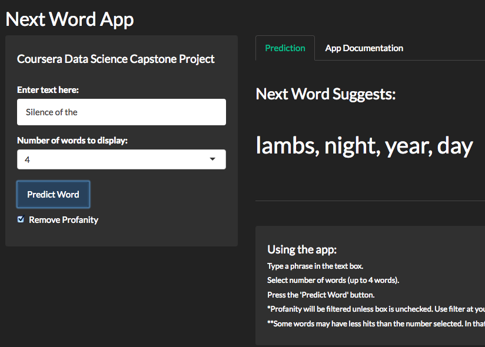

1. Type in a phrase on the text box.
2. Select the number of words to be displayed.
3. Press the “Predict Word” button.

The app predicts up to 4 words shown to the right of the text input box.

### Behind the Hood

- The text input is preprocessed to remove unwanted characters such as numbers, non-english characters, punctuation (except apostrophes), etc.
- The last four words are selected and the 1-4 grams are matched with the training data.
- A score is assigned to each hit depending on its Maximum Likelihood Estimator (MLE) and the ngram used to match the word using the following equation and an *alpha* value equal to 0.4:  
  \( Score = \begin{cases} \frac {freq(w_i)_{n=k+1}} {freq(w_{i-k}^{i-1})_{n=k+1}} & \text{if } freq(w_{i-k}^i)_{n=k+1} > 0 \\ \alpha \frac {freq(w_i)_{n=k}} {freq(w_{i-(k-1)}^{i-1})_{n=k}} & \text{otherwise} \end{cases} \)
- The words with the highest scores are returned.